# Linear Mixed Model (SAS)

Author

Sean Vieau

Published

December 17, 2024

# Introduction

The objective of this project is to **gain experience in the application of Linear Mixed Models** for statistical analysis. We are replicating this analysis in SAS.

This is the exact same data set as Project 2. Please see Project 2 - MLR with Confounding and Interaction for a detailed description of the data cleaning process.

## Project Description

The aim of the current study is to assess how treatment response differs for HIV+ patients 2 years after initiating Highly Active Antiretroviral Therapy (HAART) based on hard drug usage (such as heroin or cocaine). This study is of particular scientific interest because it is unclear whether the use of hard drugs inhibits the immune system in humans; treatment strategies may differ based on these results. The researchers are interested in comparing subjects who never used hard drugs to current hard drug users (those that use hard drugs at year 2) or previous hard drug users (those who used drugs at year 0 or 1). Outcomes of interest are: viral load (HIV copies in a mL of blood), CD4+ T cell count (a measure of immunologic health), and aggregate physical and quality of life scores from the SF-36.

The clinical hypothesis is that, if hard drugs inhibit the immune system in humans, subjects who currently or previously used hard drugs will have higher viral load and lower CD4+ T cell counts than those who never used hard drugs. Additionally, the researchers are interested in knowing if potential differences between the drug use groups can be explained by differences in adherence to the treatment regimen. The researchers are agnostic on how quality of life changes after treatment, since side effects of the treatment are significant.

The project description provided by the PI is available below:

[figure not shown]

# Linear Mixed Models

Note: This information is taken from the class notes for BIOS 6612: Applied Biostatistics II (Week 15, Lecture 24 and 25).

Linear Mixed Models are a powerful statistical tool to handle correlated data. That is, when the assumption of independence is not met, as in longitudinal data (all of the values for the same subject will be highly correlated), we can no longer run a simple regression. This is where LMM’s come in.

LMM’s are the most flexible method for analyzing repeated measures/correlated/longitudinal data. This is because:

- They allow for continuous predictors for repeated measures.
  - That is, time can now be treated as a continuous variable (whereas in RM ANOVA, predictors must be categorical).
- Missing data are allowed in LMMs, because subjects are weighted according to their number of measurements over time.
- They allow for heteroskedasticity (if you use an unstructured covariance matrix).
- Finally, LMM’s allow for random intercepts and random slopes.

### Random Intercepts

Random intercepts allow for each subject to have their own intercept, which arguably makes the model easier to interpret.

Random intercepts can be visualized below.

[figure not shown]

### Random Slopes

Random slopes allow you to account for the fact that the slope for the outcome variable will differ for each individual subject.

Including random intercepts and slopes can be visualized below.

[figure not shown]

Thus, including random intercepts and slopes allows for us to interpret the relationship between a predictor and an outcome, “with the addition of subject-specific means”. Basically, they allow you to capture variability between subjects.

[figure not shown]

# Data Preparation

## Connect to SAS

```r
# This code connects to SAS On Demand
library(configSAS)
configSAS::set_sas_engine()
```

```
Using SAS Config named: oda
SAS Connection established. Subprocess id is 35652
```

````r
#  This code allows you to run ```{sas}``` chunks
sas = knitr::opts_chunk$get("sas")
````

## Create Library

```sas
* Create library;
%LET CourseRoot = /home/u63376223/sasuser.v94/Advanced Data Analysis;
LIBNAME Proj2LMM "&CourseRoot/Project 2 LMM";
```

## Read in Data

```sas
* Import the dataset;
PROC IMPORT
    DATAFILE = "&CourseRoot/Project 2 LMM/Proj2_data_2_cleaned.csv"
    OUT = Proj2LMM.data
    REPLACE;
    GETNAMES = YES;
    RUN;

* Drop the extraneous VAR1 column;
DATA Proj2LMM.data;
    SET Proj2LMM.data;
    DROP VAR1;
    RUN;
```

## Handle NA Values

```sas
* Fix missing values;
DATA Proj2LMM.data;
    SET Proj2LMM.data;
    if hard_drugs = "NA" then hard_drugs = "";
        else hard_drugs = hard_drugs;
    if ADH = "NA" then ADH = "";
        ELSE ADH = ADH;
    IF FRP = "NA" THEN FRP = "";
        ELSE FRP = FRP;
    RUN;
```

## Examine Data Set

```sas
* Examine header;
PROC PRINT DATA = Proj2LMM.data (OBS = 6);
    RUN;
```

**lst**

<!DOCTYPE html>

The SAS System

| Obs | newid | AGG_MENT | AGG_PHYS | HASHV | HASHF | BMI | LIV34 | FRP | CESD | DKGRP | LEU3N | VLOAD | ADH | EDUCBAS | hivpos | age | ART | everART | years | hard_drugs | VLOAD_log | LEU3N_log | LEU3N_standard | LEU3N_orderNorm | LEU3N_boxcox | LEU3N_yeojohnson | AGG_MENT_orderNorm | AGG_PHYS_orderNorm | BMI_outlier | … |
| --- | --- | --- | --- | --- | --- | --- | --- | --- | --- | --- | --- | --- | --- | --- | --- | --- | --- | --- | --- | --- | --- | --- | --- | --- | --- | --- | --- | --- | --- | --- |
| 1 | 1 | 44.90709633 | 52.52556921 | No | NA | 24.71755909 | No | No | 14 | None | 104.1659454 | 102013 |  | At least one year college but no degree | 1 | 52 | 0 | 0 | 0 | Yes | 11.532855535 | 4.6459852563 | -1.42534825 | -1.564570348 | -1.6864492 | -1.791855452 | -0.325883903 | -0.026750748 | FALSE | … |
| 2 | 1 | 58.20753602 | 41.29346502 | No | Less Often | 26.06800717 | No | No | 2 | >13 drinks/week | 262.0060502 | 27 | 95-99% | At least one year college but no degree | 1 | 53 | 1 | 1 | 1 | No | 3.295836866 | 5.5683675959 | -0.803739256 | -0.80590283 | -0.751743565 | -0.690930883 | 0.9992307421 | -0.858070277 | FALSE | … |
| 3 | 1 | 59.65135974 | 48.54453213 | No | Never | 27.16420923 | No | No | 1 | None | 345.4009918 | 60 | 100% | At least one year college but no degree | 1 | 54 | 1 | 1 | 2 | No | 4.0943445622 | 5.8447060372 | -0.475311662 | -0.42189608 | -0.364691713 | -0.288979274 | 1.326252431 | -0.371364781 | FALSE | … |
| 4 | 2 | 46.34189863 | 27.92331491 | No | Never | 26.66936015 | No | Yes | 20 | None | 257.8277832 | 8121 |  | 9,10, or 11th grade | 1 | 54 | 0 | 0 | 0 | Yes | 9.0022085783 | 5.5522918551 | -0.820194189 | -0.821113591 | -0.772479637 | -0.713187968 | -0.247826962 | -1.765742707 | FALSE | … |
| 5 | 2 | 48.71790642 | 38.03806704 | Yes | Never | 25.96576195 | No | No | 18 | >13 drinks/week | 459.4561691 | 21 | 100% | 9,10, or 11th grade | 1 | 55 | 1 | 1 | 1 | No | 3.0445224377 | 6.130043549 | -0.026137328 | 0.0992729637 | 0.1026213079 | 0.1669827951 | -0.112577084 | -1.105593651 | FALSE | … |
| 6 | 2 | 45.41482533 | 37.32203958 | No | Never | 26.96036793 | No | No | 18 | 4-13 drinks/week | 263.0692533 | 48 | 100% | 9,10, or 11th grade | 1 | 56 | 1 | 1 | 2 | No | 3.8712010109 | 5.572417318 | -0.799552128 | -0.799440785 | -0.746490508 | -0.68530504 | -0.295407078 | -1.175901733 | FALSE | … |

**log**

```
11                                                         The SAS System                      Friday, December 19, 2025 03:23:00 AM

185        ods listing close;ods html5 (id=saspy_internal) file=_tomods1 options(bitmap_mode='inline') device=svg style=HTMLBlue;
185      ! ods graphics on / outputfmt=png;
186
187        * Examine header;
188        PROC PRINT DATA = Proj2LMM.data (OBS = 6);
189            RUN;
190
191
192        ods html5 (id=saspy_internal) close;ods listing;
193
12                                                         The SAS System                      Friday, December 19, 2025 03:23:00 AM

194
```

# Variable Creation

## Hard Drug Use Group

- Never User: Did not use hard drugs at any time point
- Previous User: Used hard drugs at time points 0 or 1, but not 2.
- Current User: Used hard drugs at time point 2.

#### Create Hard Drug Use Group

```sas
* Create hard drugs use group;
PROC SQL;
    CREATE TABLE data_2_grouped AS
    SELECt newid,
           hard_drugs,
           years,
           CASE
               WHEN max(CASE WHEN hard_drugs = 'Yes' AND years = 2 THEN 1 ELSE 0 END) > 0 THEN 'Current User'
               WHEN max(CASE WHEN hard_drugs = 'Yes' AND (years = 0 OR years = 1) THEN 1 ELSE 0 END) > 0 AND
                    max(case when hard_drugs = 'No' AND years = 2 THEN 1 ELSE 0 END) > 0 THEN 'Previous User'
               ELSE 'Never User'
           END AS hard_drugs_grp
    FROM PROJ2LMM.data
    GROUP BY newid
    ORDER BY newid, years;
QUIT;
```

#### Append to Original Data Set

```sas
* Append to original data set;
DATA Proj2LMM.Data;
    MERGE Proj2LMM.Data(IN = A) data_2_grouped(IN = B);
    BY newid;
    IF A;
    RUN;
```

#### Double Check Classification

```sas
* Double check classification;
* This matches the previous analysis in R;
PROC TABULATE DATA = Proj2LMM.data;
    CLASS hard_drugs_grp;
    TABLE hard_drugs_grp;
    RUN;
```

**lst**

<!DOCTYPE html>

The SAS System

| hard_drugs_grp Current User N | hard_drugs_grp Never User N | hard_drugs_grp Previous User N |
| --- | --- | --- |
| 180 | 1332 | 138 |

**log**

```
17                                                         The SAS System                      Friday, December 19, 2025 03:23:00 AM

239        ods listing close;ods html5 (id=saspy_internal) file=_tomods1 options(bitmap_mode='inline') device=svg style=HTMLBlue;
239      ! ods graphics on / outputfmt=png;
240
241        * Double check classification;
242        * This matches the previous analysis in R;
243        PROC TABULATE DATA = Proj2LMM.data;
244         CLASS hard_drugs_grp;
245         TABLE hard_drugs_grp;
246         RUN;
247
248
249        ods html5 (id=saspy_internal) close;ods listing;
250
18                                                         The SAS System                      Friday, December 19, 2025 03:23:00 AM

251
```

## Adherence High vs. Low

- High Adherence: >=95% Adherence to protocol
- Low Adherence: < 95 Adherence to protocol

#### Create Adherence Group

```sas
* Create adherence group;
PROC SQL;
    CREATE TABLE data_2_grouped AS
    SELECT newid,
           ADH,
           years,
           CASE
               WHEN max(case when years = 2 AND (ADH = '100%' or ADH = '95-99%') THEN 1 ELSE 0 END) = 1 THEN 'High Adherence'
               ELSE 'Low Adherence'
           END AS ADH_HIGHVSLOW
    FROM PROJ2LMM.data
    GROUP BY newid
    ORDER BY newid, years;
QUIT;
```

#### Append to Original Data Set

```sas
* Append to original data set;
DATA Proj2LMM.Data;
    MERGE Proj2LMM.Data(IN = A) data_2_grouped(IN = B);
    BY newid;
    IF A;
    RUN;
```

#### Double Check Classification

```sas
* Double check classification;
* This matches the previous analysis in R;
PROC TABULATE DATA = Proj2LMM.data;
    CLASS ADH_HIGHVSLOW;
    TABLE ADH_HIGHVSLOW;
    RUN;
```

**lst**

<!DOCTYPE html>

The SAS System

| ADH_HIGHVSLOW High Adherence N | ADH_HIGHVSLOW Low Adherence N |
| --- | --- |
| 1485 | 165 |

**log**

```
23                                                         The SAS System                      Friday, December 19, 2025 03:23:00 AM

292        ods listing close;ods html5 (id=saspy_internal) file=_tomods1 options(bitmap_mode='inline') device=svg style=HTMLBlue;
292      ! ods graphics on / outputfmt=png;
293
294        * Double check classification;
295        * This matches the previous analysis in R;
296        PROC TABULATE DATA = Proj2LMM.data;
297         CLASS ADH_HIGHVSLOW;
298         TABLE ADH_HIGHVSLOW;
299         RUN;
300
301
302        ods html5 (id=saspy_internal) close;ods listing;
303
24                                                         The SAS System                      Friday, December 19, 2025 03:23:00 AM

304
```

## Create College Education Variable

#### Create College Level

```sas
* Create college level variable;
PROC SQL;
    CREATE TABLE data_2_grouped AS
    SELECT newid,
           EDUCBAS,
           years,
           CASE
               WHEN max(case when years = 2 AND (EDUCBAS IN ("At least one year college but no degree",
                                                             "Four years college or got degree",
                                                             "Some graduate work",
                                                             "Post-graduate degree"))
                                   THEN 1 ELSE 0 END) = 1
               THEN 'College'
               ELSE 'No College'
           END AS EDUC_COLLEGE
    FROM PROJ2LMM.data
    GROUP BY newid
    ORDER BY newid, years;
QUIT;
```

#### Append to Original Data Set

```sas
* Append to original data set;
DATA Proj2LMM.Data;
    MERGE Proj2LMM.Data(IN = A) data_2_grouped(IN = B);
    BY newid;
    IF A;
    RUN;
```

#### Double Check Classification

```sas
* Double check classification;
* This matches the previous analysis in R;
PROC TABULATE DATA = Proj2LMM.data;
    CLASS EDUC_COLLEGE;
    TABLE EDUC_COLLEGE;
    RUN;
```

**lst**

<!DOCTYPE html>

The SAS System

| EDUC_COLLEGE College N | EDUC_COLLEGE No College N |
| --- | --- |
| 1275 | 375 |

**log**

```
29                                                         The SAS System                      Friday, December 19, 2025 03:23:00 AM

350        ods listing close;ods html5 (id=saspy_internal) file=_tomods1 options(bitmap_mode='inline') device=svg style=HTMLBlue;
350      ! ods graphics on / outputfmt=png;
351
352        * Double check classification;
353        * This matches the previous analysis in R;
354        PROC TABULATE DATA = Proj2LMM.data;
355         CLASS EDUC_COLLEGE;
356         TABLE EDUC_COLLEGE;
357         RUN;
358
359
360        ods html5 (id=saspy_internal) close;ods listing;
361
30                                                         The SAS System                      Friday, December 19, 2025 03:23:00 AM

362
```

# Data Visualization

## Bivariate Relationships

Here we will plot the average of each outcome group by our PEVs.

We will use SQL to calculate the averages across years (similiar to how we use the tidyverse in R).

## Main Outcome Variables

**Viral Load**

### By Hard Drug Use

#### Calculate Average Viral Load for Each Year

```sas
*** By hard drug use and year;
PROC SQL;
    CREATE TABLE summary_data as
    SELECT hard_drugs_grp,
           years,
           mean(VLOAD_log) as avg_VLOAD_log
    FROM Proj2LMM.data
    GROUP BY hard_drugs_grp, years;
    QUIT;
```

#### Create Plot

```sas
* Plot;
PROC SGPLOT DATA = summary_data;
    SERIES x = years y = avg_VLOAD_log / GROUP = hard_drugs_grp;
    XAXIS LABEL = "Years";
    YAXIS LABEL = "Average Viral Load";
    KEYLEGEND / POSITION = right ACROSS = 1 LOCATION = outside;
    TITLE "Average Viral Load by Year and Hard Drug Use Group";
    RUN;
```

**lst**

<!DOCTYPE html>

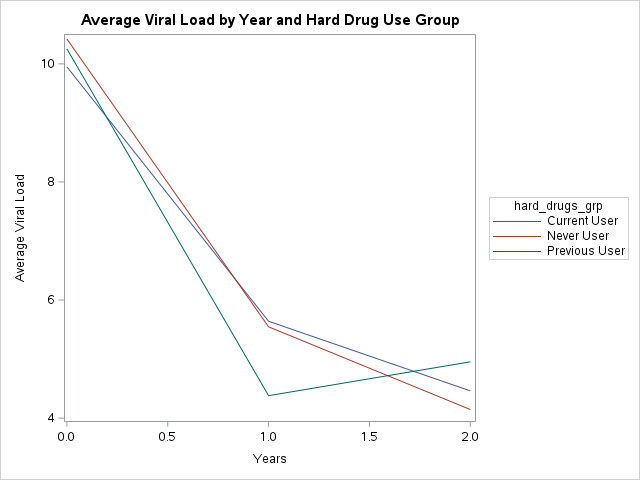

**log**

```
33                                                         The SAS System                      Friday, December 19, 2025 03:23:00 AM

383        ods listing close;ods html5 (id=saspy_internal) file=_tomods1 options(bitmap_mode='inline') device=svg style=HTMLBlue;
383      ! ods graphics on / outputfmt=png;
384
385
386        * Plot;
387        PROC SGPLOT DATA = summary_data;
388         SERIES x = years y = avg_VLOAD_log / GROUP = hard_drugs_grp;
389         XAXIS LABEL = "Years";
390         YAXIS LABEL = "Average Viral Load";
391         KEYLEGEND / POSITION = right ACROSS = 1 LOCATION = outside;
392         TITLE "Average Viral Load by Year and Hard Drug Use Group";
393         RUN;
394
395
396
397        ods html5 (id=saspy_internal) close;ods listing;
398
34                                                         The SAS System                      Friday, December 19, 2025 03:23:00 AM

399
```

### By Adherence

#### Calculate Average Viral Load for Each Year

```sas
* Calculate Averages by Adherence;
PROC SQL;
    CREATE TABLE summary_data as
    SELECT ADH_HIGHVSLOW,
           years,
           mean(VLOAD_log) as avg_VLOAD_log
    FROM Proj2LMM.data
    GROUP BY ADH_HIGHVSLOW, years;
    QUIT;
```

#### Create Plot

```sas
* Plot;
PROC SGPLOT DATA = summary_data;
    SERIES x = years y = avg_VLOAD_log / GROUP = ADH_HIGHVSLOW;
    XAXIS LABEL = "Years";
    YAXIS LABEL = "Average Viral Load";
    KEYLEGEND / POSITION = right ACROSS = 1 LOCATION = outside;
    TITLE "Average Viral Load by Year and Adherence";
    RUN;
```

**lst**

<!DOCTYPE html>

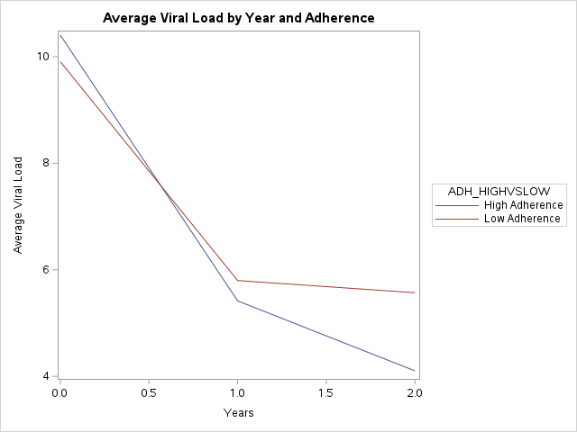

**log**

```
37                                                         The SAS System                      Friday, December 19, 2025 03:23:00 AM

420        ods listing close;ods html5 (id=saspy_internal) file=_tomods1 options(bitmap_mode='inline') device=svg style=HTMLBlue;
420      ! ods graphics on / outputfmt=png;
421
422        * Plot;
423        PROC SGPLOT DATA = summary_data;
424         SERIES x = years y = avg_VLOAD_log / GROUP = ADH_HIGHVSLOW;
425         XAXIS LABEL = "Years";
426         YAXIS LABEL = "Average Viral Load";
427         KEYLEGEND / POSITION = right ACROSS = 1 LOCATION = outside;
428         TITLE "Average Viral Load by Year and Adherence";
429         RUN;
430
431
432        ods html5 (id=saspy_internal) close;ods listing;
433
38                                                         The SAS System                      Friday, December 19, 2025 03:23:00 AM

434
```

Top of Tabset

**CD4+ T Cell Count**

### By Hard Drug Use

#### Calculate Average CD4+ T Cell Count for Each Year

```sas
*** By hard drug use;
PROC SQL;
    CREATE TABLE summary_data as
    SELECT hard_drugs_grp,
           years,
           mean(LEU3N) as avg_LEU3N
    FROM Proj2LMM.data
    GROUP BY hard_drugs_grp, years;
    QUIT;
```

#### Create Plot

```sas
* Plot;
PROC SGPLOT DATA = summary_data;
    SERIES x = years y = avg_LEU3N / GROUP = hard_drugs_grp;
    XAXIS LABEL = "Years";
    YAXIS LABEL = "Average CD4+ T Cell Count";
    KEYLEGEND / POSITION = right ACROSS = 1 LOCATION = outside;
    TITLE "Average CD4+ T Cell Count by Year and Hard Drug Use Group";
    RUN;
```

**lst**

<!DOCTYPE html>

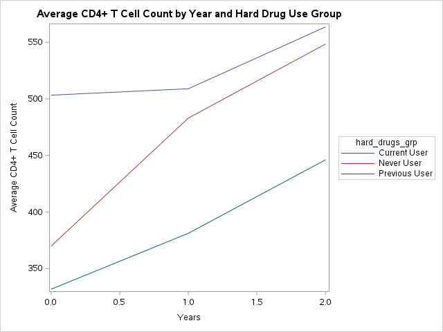

**log**

```
41                                                         The SAS System                      Friday, December 19, 2025 03:23:00 AM

455        ods listing close;ods html5 (id=saspy_internal) file=_tomods1 options(bitmap_mode='inline') device=svg style=HTMLBlue;
455      ! ods graphics on / outputfmt=png;
456
457        * Plot;
458        PROC SGPLOT DATA = summary_data;
459         SERIES x = years y = avg_LEU3N / GROUP = hard_drugs_grp;
460         XAXIS LABEL = "Years";
461         YAXIS LABEL = "Average CD4+ T Cell Count";
462         KEYLEGEND / POSITION = right ACROSS = 1 LOCATION = outside;
463         TITLE "Average CD4+ T Cell Count by Year and Hard Drug Use Group";
464         RUN;
465
466
467        ods html5 (id=saspy_internal) close;ods listing;
468
42                                                         The SAS System                      Friday, December 19, 2025 03:23:00 AM

469
```

### By Adherence

#### Calculate Average CD4+ T Cell Count for Each Year

```sas
* Calculate averages for each year;
PROC SQL;
    CREATE TABLE summary_data as
    SELECT ADH_HIGHVSLOW,
           years,
           mean(LEU3N) as avg_LEU3N
    FROM Proj2LMM.data
    GROUP BY ADH_HIGHVSLOW, years;
    QUIT;
```

#### Create Plot

```sas
* Plot;
PROC SGPLOT DATA = summary_data;
    SERIES x = years y = avg_LEU3N / GROUP = ADH_HIGHVSLOW;
    XAXIS LABEL = "Years";
    YAXIS LABEL = "Average CD4+ T Cell Count";
    KEYLEGEND / POSITION = right ACROSS = 1 LOCATION = outside;
    TITLE "Average CD4+ T Cell Count by Year and Adherence";
    RUN;
```

**lst**

<!DOCTYPE html>

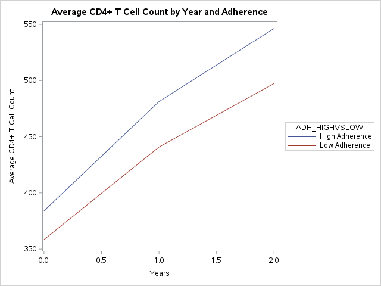

**log**

```
45                                                         The SAS System                      Friday, December 19, 2025 03:23:00 AM

490        ods listing close;ods html5 (id=saspy_internal) file=_tomods1 options(bitmap_mode='inline') device=svg style=HTMLBlue;
490      ! ods graphics on / outputfmt=png;
491
492        * Plot;
493        PROC SGPLOT DATA = summary_data;
494         SERIES x = years y = avg_LEU3N / GROUP = ADH_HIGHVSLOW;
495         XAXIS LABEL = "Years";
496         YAXIS LABEL = "Average CD4+ T Cell Count";
497         KEYLEGEND / POSITION = right ACROSS = 1 LOCATION = outside;
498         TITLE "Average CD4+ T Cell Count by Year and Adherence";
499         RUN;
500
501
502        ods html5 (id=saspy_internal) close;ods listing;
503
46                                                         The SAS System                      Friday, December 19, 2025 03:23:00 AM

504
```

Top of Tabset

**Mental QOL**

### By Hard Drug Use

#### Calculate Average Mental QOL Each Year

```sas
* Calculate the average AGG_MENT for each hard_drugs_grp and year;
PROC SQL;
    CREATE TABLE summary_data as
    SELECT hard_drugs_grp,
           years,
           mean(AGG_MENT) as avg_AGG_MENT
    FROM Proj2LMM.data
    GROUP BY hard_drugs_grp, years;
    QUIT;
```

#### Create Plot

```sas
* Plot;
PROC SGPLOT DATA = summary_data;
    SERIES x = years y = avg_AGG_MENT / GROUP = hard_drugs_grp;
    XAXIS LABEL = "Years";
    YAXIS LABEL = "Average Mental QOL";
    KEYLEGEND / POSITION = right ACROSS = 1 LOCATION = outside;
    TITLE "Average Mental Quality of Life by Year and Hard Drug Use Group";
    RUN;
```

**lst**

<!DOCTYPE html>

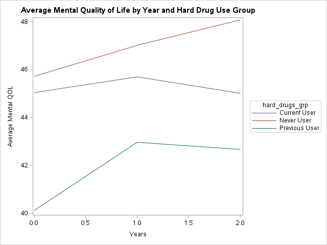

**log**

```
49                                                         The SAS System                      Friday, December 19, 2025 03:23:00 AM

525        ods listing close;ods html5 (id=saspy_internal) file=_tomods1 options(bitmap_mode='inline') device=svg style=HTMLBlue;
525      ! ods graphics on / outputfmt=png;
526
527        * Plot;
528        PROC SGPLOT DATA = summary_data;
529         SERIES x = years y = avg_AGG_MENT / GROUP = hard_drugs_grp;
530         XAXIS LABEL = "Years";
531         YAXIS LABEL = "Average Mental QOL";
532         KEYLEGEND / POSITION = right ACROSS = 1 LOCATION = outside;
533         TITLE "Average Mental Quality of Life by Year and Hard Drug Use Group";
534         RUN;
535
536
537        ods html5 (id=saspy_internal) close;ods listing;
538
50                                                         The SAS System                      Friday, December 19, 2025 03:23:00 AM

539
```

### By Adherence

#### Calculate Average Mental QOL Each Year

```sas
* Calculate the average for each year;
PROC SQL;
    CREATE TABLE summary_data AS
    SELECT ADH_HIGHVSLOW,
           years,
           mean(AGG_MENT) AS avg_AGG_MENT
    FROM Proj2LMM.data
    GROUP BY ADH_HIGHVSLOW, years;
    QUIT;
```

#### Create Plot

```sas
* Plot;
PROC SGPLOT DATA = summary_data;
    SERIES x = years y = avg_AGG_MENT / GROUP = ADH_HIGHVSLOW;
    XAXIS LABEL = "Years";
    YAXIS LABEL = "Average Mental QOL";
    KEYLEGEND / POSITION = right ACROSS = 1 LOCATION = outside;
    TITLE "Average Mental Quality of Life by Year and Adherence";
    RUN;
```

**lst**

<!DOCTYPE html>

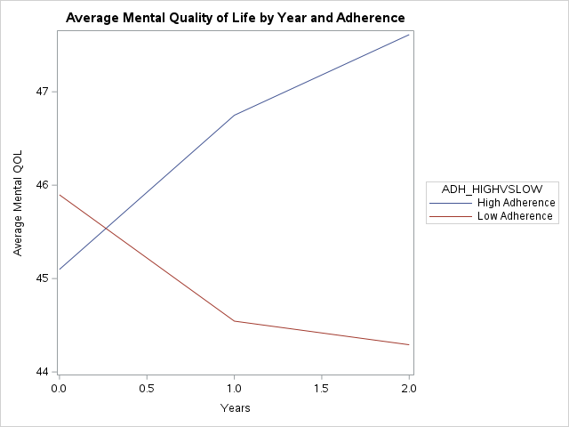

**log**

```
53                                                         The SAS System                      Friday, December 19, 2025 03:23:00 AM

560        ods listing close;ods html5 (id=saspy_internal) file=_tomods1 options(bitmap_mode='inline') device=svg style=HTMLBlue;
560      ! ods graphics on / outputfmt=png;
561
562        * Plot;
563        PROC SGPLOT DATA = summary_data;
564         SERIES x = years y = avg_AGG_MENT / GROUP = ADH_HIGHVSLOW;
565         XAXIS LABEL = "Years";
566         YAXIS LABEL = "Average Mental QOL";
567         KEYLEGEND / POSITION = right ACROSS = 1 LOCATION = outside;
568         TITLE "Average Mental Quality of Life by Year and Adherence";
569         RUN;
570
571
572        ods html5 (id=saspy_internal) close;ods listing;
573
54                                                         The SAS System                      Friday, December 19, 2025 03:23:00 AM

574
```

Top of Tabset

**Physical QOL**

### By Hard Drug Use

#### Calculate Average Physical QOL Each Year

```sas
* Calculate the average AGG_PHYS for each hard_drugs_grp and year;
PROC SQL;
    CREATE TABLE summary_data as
    SELECT hard_drugs_grp,
           years,
           mean(AGG_PHYS) as avg_AGG_PHYS
    FROM Proj2LMM.data
    GROUP BY hard_drugs_grp, years;
    QUIT;
```

#### Create Plot

```sas
* Plot;
PROC SGPLOT DATA = summary_data;
    SERIES x = years y = avg_AGG_PHYS / GROUP = hard_drugs_grp;
    XAXIS LABEL = "Years";
    YAXIS LABEL = "Average Physical QOL";
    KEYLEGEND / POSITION = right ACROSS = 1 LOCATION = outside;
    TITLE "Average Physical Quality of Life by Year and Hard Drug Use Group";
    RUN;
```

**lst**

<!DOCTYPE html>

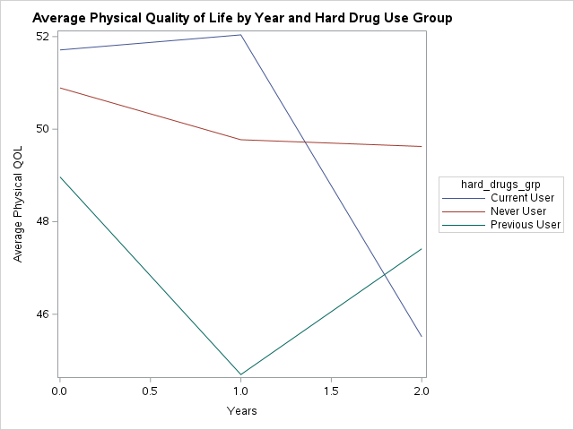

**log**

```
57                                                         The SAS System                      Friday, December 19, 2025 03:23:00 AM

595        ods listing close;ods html5 (id=saspy_internal) file=_tomods1 options(bitmap_mode='inline') device=svg style=HTMLBlue;
595      ! ods graphics on / outputfmt=png;
596
597        * Plot;
598        PROC SGPLOT DATA = summary_data;
599         SERIES x = years y = avg_AGG_PHYS / GROUP = hard_drugs_grp;
600         XAXIS LABEL = "Years";
601         YAXIS LABEL = "Average Physical QOL";
602         KEYLEGEND / POSITION = right ACROSS = 1 LOCATION = outside;
603         TITLE "Average Physical Quality of Life by Year and Hard Drug Use Group";
604         RUN;
605
606
607        ods html5 (id=saspy_internal) close;ods listing;
608
58                                                         The SAS System                      Friday, December 19, 2025 03:23:00 AM

609
```

### By Adherence

#### Calculate Average Physical QOL Each Year

```sas
* Calculate the average for each year;
PROC SQL;
    CREATE TABLE summary_data AS
    SELECT ADH_HIGHVSLOW,
           years,
           mean(AGG_PHYS) AS avg_AGG_PHYS
    FROM Proj2LMM.data
    GROUP BY ADH_HIGHVSLOW, years;
    QUIT;
```

#### Create Plot

```sas
* Plot;
PROC SGPLOT DATA = summary_data;
    SERIES x = years y = avg_AGG_PHYS / GROUP = ADH_HIGHVSLOW;
    XAXIS LABEL = "Years";
    YAXIS LABEL = "Average Physical QOL";
    KEYLEGEND / POSITION = right ACROSS = 1 LOCATION = outside;
    TITLE "Average Physical Quality of Life by Year and Adherence";
    RUN;
```

**lst**

<!DOCTYPE html>

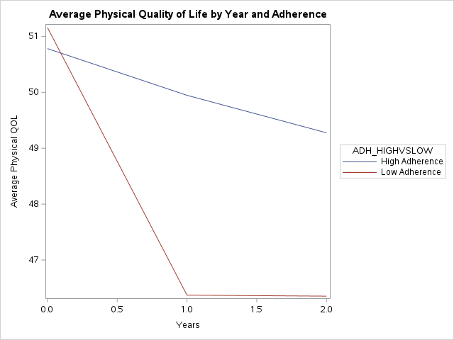

**log**

```
61                                                         The SAS System                      Friday, December 19, 2025 03:23:00 AM

630        ods listing close;ods html5 (id=saspy_internal) file=_tomods1 options(bitmap_mode='inline') device=svg style=HTMLBlue;
630      ! ods graphics on / outputfmt=png;
631
632        * Plot;
633        PROC SGPLOT DATA = summary_data;
634         SERIES x = years y = avg_AGG_PHYS / GROUP = ADH_HIGHVSLOW;
635         XAXIS LABEL = "Years";
636         YAXIS LABEL = "Average Physical QOL";
637         KEYLEGEND / POSITION = right ACROSS = 1 LOCATION = outside;
638         TITLE "Average Physical Quality of Life by Year and Adherence";
639         RUN;
640
641
642        ods html5 (id=saspy_internal) close;ods listing;
643
62                                                         The SAS System                      Friday, December 19, 2025 03:23:00 AM

644
```

Top of Tabset

**Summary**

For adherence, those with low adherence have:

- The highest average log viral load
- The lowest leukocyte count, and lowest mental and physical QOL.

Top of Tabset

## Covariates

**Depression**

Depression was a confounder in the model for mental QOL and must be accounted for.

### By Hard Drugs

#### Calculate Average Depression Scores for Each Year

```sas
* Calculate the average for each year;
PROC SQL;
    CREATE TABLE summary_data AS
    SELECT hard_drugs_grp,
           years,
           mean(CESD) AS avg_CESD
    FROM Proj2LMM.data
    GROUP BY hard_drugs_grp, years;
    QUIT;
```

#### Create Plot

```sas
* Plot;
PROC SGPLOT DATA = summary_data;
    SERIES x = years y = avg_CESD / GROUP = hard_drugs_grp;
    XAXIS LABEL = "Years";
    YAXIS LABEL = "Average Depresion Score";
    KEYLEGEND / POSITION = right ACROSS = 1 LOCATION = outside;
    TITLE "Average Depression Score by Year and Hard Drugs Use";
    RUN;
```

**lst**

<!DOCTYPE html>

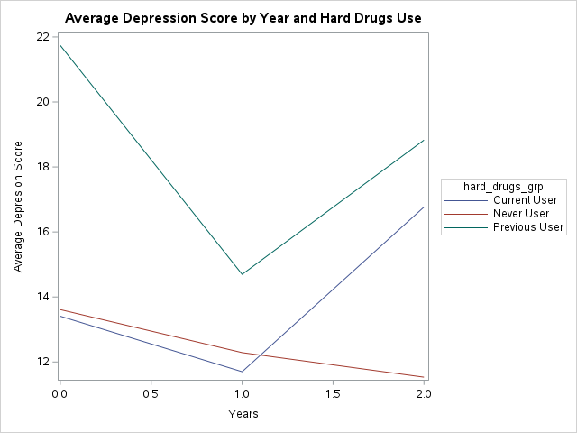

**log**

```
65                                                         The SAS System                      Friday, December 19, 2025 03:23:00 AM

665        ods listing close;ods html5 (id=saspy_internal) file=_tomods1 options(bitmap_mode='inline') device=svg style=HTMLBlue;
665      ! ods graphics on / outputfmt=png;
666
667        * Plot;
668        PROC SGPLOT DATA = summary_data;
669         SERIES x = years y = avg_CESD / GROUP = hard_drugs_grp;
670         XAXIS LABEL = "Years";
671         YAXIS LABEL = "Average Depresion Score";
672         KEYLEGEND / POSITION = right ACROSS = 1 LOCATION = outside;
673         TITLE "Average Depression Score by Year and Hard Drugs Use";
674         RUN;
675
676
677        ods html5 (id=saspy_internal) close;ods listing;
678
66                                                         The SAS System                      Friday, December 19, 2025 03:23:00 AM

679
```

### By Adherence

#### Calculate Average Depression Score for Each Year

```sas
* Calculate the average for each year;
PROC SQL;
    CREATE TABLE summary_data AS
    SELECT ADH_HIGHVSLOW,
           years,
           mean(CESD) AS avg_CESD
    FROM Proj2LMM.data
    GROUP BY ADH_HIGHVSLOW, years;
    QUIT;
```

#### Create Plot

```sas
PROC SGPLOT DATA = summary_data;
    SERIES x = years y = avg_CESD / GROUP = ADH_HIGHVSLOW;
    XAXIS LABEL = "Years";
    YAXIS LABEL = "Average Depresion Score";
    KEYLEGEND / POSITION = right ACROSS = 1 LOCATION = outside;
    TITLE "Average Depression Score by Year and Adherence";
    RUN;
```

**lst**

<!DOCTYPE html>

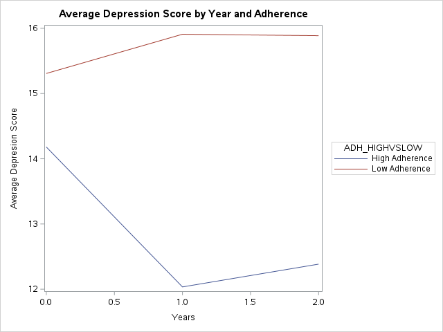

**log**

```
69                                                         The SAS System                      Friday, December 19, 2025 03:23:00 AM

700        ods listing close;ods html5 (id=saspy_internal) file=_tomods1 options(bitmap_mode='inline') device=svg style=HTMLBlue;
700      ! ods graphics on / outputfmt=png;
701
702        PROC SGPLOT DATA = summary_data;
703         SERIES x = years y = avg_CESD / GROUP = ADH_HIGHVSLOW;
704         XAXIS LABEL = "Years";
705         YAXIS LABEL = "Average Depresion Score";
706         KEYLEGEND / POSITION = right ACROSS = 1 LOCATION = outside;
707         TITLE "Average Depression Score by Year and Adherence";
708         RUN;
709
710
711        ods html5 (id=saspy_internal) close;ods listing;
712
70                                                         The SAS System                      Friday, December 19, 2025 03:23:00 AM

713
```

Top of Tabset

**Frailty Related Phenotype**

Frailty Related Phenotype is a precision variable for physical QOL, and was previously significant for CD4+ T Cell Count.

### CD4+ T Cell Count

#### Calculate Averages for Each Year

```sas
*** CD4+ T Cell Count;
* Calculate the average for each year;
PROC SQL;
    CREATE TABLE summary_data AS
    SELECT FRP,
           years,
           mean(LEU3N) AS avg_LEU3N
    FROM Proj2LMM.data
    WHERE FRP IS NOT MISSING
    GROUP BY FRP, years;
    QUIT;
```

#### Create Plot

```sas
* Plot;
PROC SGPLOT DATA = summary_data;
    SERIES x = years y = avg_LEU3N / GROUP = frp;
    XAXIS LABEL = "Years";
    YAXIS LABEL = "Average CD4+ T Cell Count";
    KEYLEGEND / POSITION = right ACROSS = 1 LOCATION = outside;
    TITLE "Average CD4+ T Cell Count by Year and Frailty Related Phenotype";
    RUN;
```

**lst**

<!DOCTYPE html>

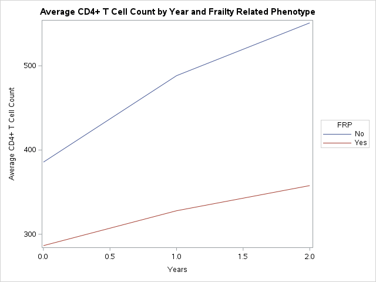

**log**

```
73                                                         The SAS System                      Friday, December 19, 2025 03:23:00 AM

736        ods listing close;ods html5 (id=saspy_internal) file=_tomods1 options(bitmap_mode='inline') device=svg style=HTMLBlue;
736      ! ods graphics on / outputfmt=png;
737
738        * Plot;
739        PROC SGPLOT DATA = summary_data;
740         SERIES x = years y = avg_LEU3N / GROUP = frp;
741         XAXIS LABEL = "Years";
742         YAXIS LABEL = "Average CD4+ T Cell Count";
743         KEYLEGEND / POSITION = right ACROSS = 1 LOCATION = outside;
744         TITLE "Average CD4+ T Cell Count by Year and Frailty Related Phenotype";
745         RUN;
746
747
748        ods html5 (id=saspy_internal) close;ods listing;
749
74                                                         The SAS System                      Friday, December 19, 2025 03:23:00 AM

750
```

### Physical QOL

```sas
*** Physical QOL;
PROC SQL;
    CREATE TABLE summary_data AS
    SELECT FRP,
           years,
           mean(AGG_PHYS) AS avg_AGG_PHYS
    FROM Proj2LMM.data
    WHERE FRP IS NOT MISSING
    GROUP BY FRP, years;
    QUIT;
```

#### Create Plot

```sas
* Plot;
PROC SGPLOT DATA = summary_data;
    SERIES x = years y = avg_AGG_PHYS / GROUP = frp;
    XAXIS LABEL = "Years";
    YAXIS LABEL = "Average Physical QOL";
    KEYLEGEND / POSITION = right ACROSS = 1 LOCATION = outside;
    TITLE "Average Physical QOL by Year and Frailty Related Phenotype";
    RUN;
```

**lst**

<!DOCTYPE html>

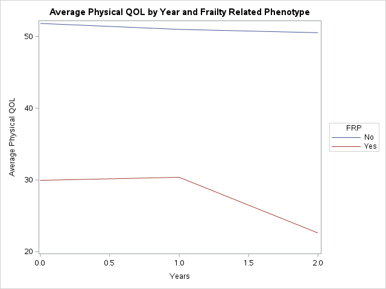

**log**

```
77                                                         The SAS System                      Friday, December 19, 2025 03:23:00 AM

772        ods listing close;ods html5 (id=saspy_internal) file=_tomods1 options(bitmap_mode='inline') device=svg style=HTMLBlue;
772      ! ods graphics on / outputfmt=png;
773
774        * Plot;
775        PROC SGPLOT DATA = summary_data;
776         SERIES x = years y = avg_AGG_PHYS / GROUP = frp;
777         XAXIS LABEL = "Years";
778         YAXIS LABEL = "Average Physical QOL";
779         KEYLEGEND / POSITION = right ACROSS = 1 LOCATION = outside;
780         TITLE "Average Physical QOL by Year and Frailty Related Phenotype";
781         RUN;
782
783
784        ods html5 (id=saspy_internal) close;ods listing;
785
78                                                         The SAS System                      Friday, December 19, 2025 03:23:00 AM

786
```

Top of Tabset

**College Education**

This was significant for the model with VLOAD_log. Let’s assess.

### Viral Load

#### Calculate Average Viral Load

```sas
*** Viral Load;
PROC SQL;
    CREATE TABLE summary_data AS
    SELECT EDUC_COLLEGE,
           years,
           mean(VLOAD_log) AS avg_VLOAD_log
    FROM Proj2LMM.data
    GROUP BY EDUC_COLLEGE, years;
    QUIT;
```

#### Create Plot

```sas
* Plot;
PROC SGPLOT DATA = summary_data;
    SERIES x = years y = avg_VLOAD_log / GROUP = EDUC_COLLEGE;
    XAXIS LABEL = "Years";
    YAXIS LABEL = "Average Viral Load";
    KEYLEGEND / POSITION = right ACROSS = 1 LOCATION = outside;
    TITLE "Average Viral Load by Year and College Education";
    RUN;
```

**lst**

<!DOCTYPE html>

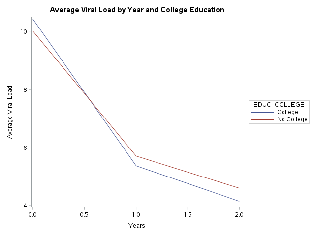

**log**

```
81                                                         The SAS System                      Friday, December 19, 2025 03:23:00 AM

807        ods listing close;ods html5 (id=saspy_internal) file=_tomods1 options(bitmap_mode='inline') device=svg style=HTMLBlue;
807      ! ods graphics on / outputfmt=png;
808
809        * Plot;
810        PROC SGPLOT DATA = summary_data;
811         SERIES x = years y = avg_VLOAD_log / GROUP = EDUC_COLLEGE;
812         XAXIS LABEL = "Years";
813         YAXIS LABEL = "Average Viral Load";
814         KEYLEGEND / POSITION = right ACROSS = 1 LOCATION = outside;
815         TITLE "Average Viral Load by Year and College Education";
816         RUN;
817
818
819        ods html5 (id=saspy_internal) close;ods listing;
820
82                                                         The SAS System                      Friday, December 19, 2025 03:23:00 AM

821
```

#### Calculate Average CD4+ T Cell Count

```sas
*** CD4+ T Cell Count;
PROC SQL;
    CREATE TABLE summary_data AS
    SELECT EDUC_COLLEGE,
           years,
           mean(LEU3N) AS avg_LEU3N
    FROM Proj2LMM.data
    GROUP BY EDUC_COLLEGE, years;
    QUIT;
```

#### Create Plot

```sas
* Plot;
PROC SGPLOT DATA = summary_data;
    SERIES x = years y = avg_LEU3N / GROUP = EDUC_COLLEGE;
    XAXIS LABEL = "Years";
    YAXIS LABEL = "Average CD4+ T Cell Count";
    KEYLEGEND / POSITION = right ACROSS = 1 LOCATION = outside;
    TITLE "Average CD4+ T Cell Count by Year and College Education";
    RUN;
```

**lst**

<!DOCTYPE html>

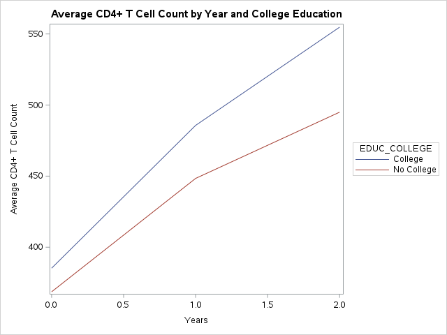

**log**

```
85                                                         The SAS System                      Friday, December 19, 2025 03:23:00 AM

842        ods listing close;ods html5 (id=saspy_internal) file=_tomods1 options(bitmap_mode='inline') device=svg style=HTMLBlue;
842      ! ods graphics on / outputfmt=png;
843
844        * Plot;
845        PROC SGPLOT DATA = summary_data;
846         SERIES x = years y = avg_LEU3N / GROUP = EDUC_COLLEGE;
847         XAXIS LABEL = "Years";
848         YAXIS LABEL = "Average CD4+ T Cell Count";
849         KEYLEGEND / POSITION = right ACROSS = 1 LOCATION = outside;
850         TITLE "Average CD4+ T Cell Count by Year and College Education";
851         RUN;
852
853
854        ods html5 (id=saspy_internal) close;ods listing;
855
86                                                         The SAS System                      Friday, December 19, 2025 03:23:00 AM

856
```

### Mental Quality of Life

#### Calculate Average Mental Quality of Life

```sas
*** Mental QOL;
PROC SQL;
    CREATE TABLE summary_data AS
    SELECT EDUC_COLLEGE,
           years,
           mean(AGG_MENT) AS avg_AGG_MENT
    FROM Proj2LMM.data
    GROUP BY EDUC_COLLEGE, years;
    QUIT;
```

#### Create Plot

```sas
* Plot;
PROC SGPLOT DATA = summary_data;
    SERIES x = years y = avg_AGG_MENT / GROUP = EDUC_COLLEGE;
    XAXIS LABEL = "Years";
    YAXIS LABEL = "Average Mental QOL";
    KEYLEGEND / POSITION = right ACROSS = 1 LOCATION = outside;
    TITLE "Average Mental QOL by Year and College Education";
    RUN;
```

**lst**

<!DOCTYPE html>

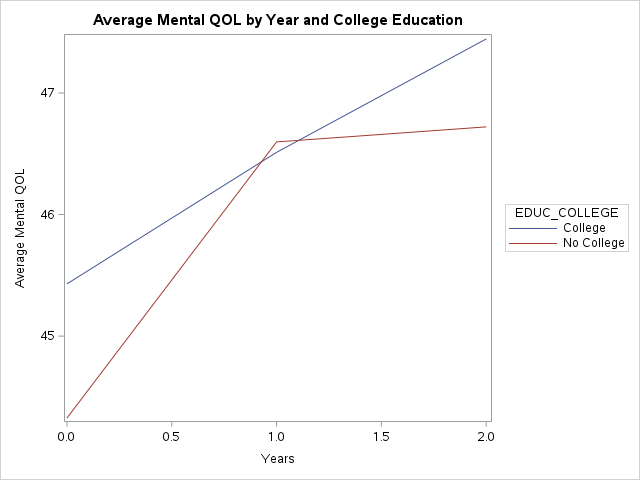

**log**

```
89                                                         The SAS System                      Friday, December 19, 2025 03:23:00 AM

877        ods listing close;ods html5 (id=saspy_internal) file=_tomods1 options(bitmap_mode='inline') device=svg style=HTMLBlue;
877      ! ods graphics on / outputfmt=png;
878
879        * Plot;
880        PROC SGPLOT DATA = summary_data;
881         SERIES x = years y = avg_AGG_MENT / GROUP = EDUC_COLLEGE;
882         XAXIS LABEL = "Years";
883         YAXIS LABEL = "Average Mental QOL";
884         KEYLEGEND / POSITION = right ACROSS = 1 LOCATION = outside;
885         TITLE "Average Mental QOL by Year and College Education";
886         RUN;
887
888
889        ods html5 (id=saspy_internal) close;ods listing;
890
90                                                         The SAS System                      Friday, December 19, 2025 03:23:00 AM

891
```

### Physical Quality of Life

#### Calculate Average Quality of Life

```sas
*** Physical QOL;
PROC SQL;
    CREATE TABLE summary_data AS
    SELECT EDUC_COLLEGE,
           years,
           mean(AGG_PHYS) AS avg_AGG_PHYS
    FROM Proj2LMM.data
    GROUP BY EDUC_COLLEGE, years;
    QUIT;
```

#### Create Plot

```sas
* Plot;
PROC SGPLOT DATA = summary_data;
    SERIES x = years y = avg_AGG_PHYS / GROUP = EDUC_COLLEGE;
    XAXIS LABEL = "Years";
    YAXIS LABEL = "Average Physical QOL";
    KEYLEGEND / POSITION = right ACROSS = 1 LOCATION = outside;
    TITLE "Average Physical QOL by Year and College Education";
    RUN;
```

**lst**

<!DOCTYPE html>

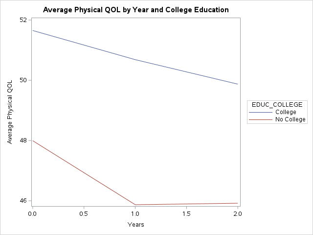

**log**

```
93                                                         The SAS System                      Friday, December 19, 2025 03:23:00 AM

912        ods listing close;ods html5 (id=saspy_internal) file=_tomods1 options(bitmap_mode='inline') device=svg style=HTMLBlue;
912      ! ods graphics on / outputfmt=png;
913
914        * Plot;
915        PROC SGPLOT DATA = summary_data;
916         SERIES x = years y = avg_AGG_PHYS / GROUP = EDUC_COLLEGE;
917         XAXIS LABEL = "Years";
918         YAXIS LABEL = "Average Physical QOL";
919         KEYLEGEND / POSITION = right ACROSS = 1 LOCATION = outside;
920         TITLE "Average Physical QOL by Year and College Education";
921         RUN;
922
923
924        ods html5 (id=saspy_internal) close;ods listing;
925
94                                                         The SAS System                      Friday, December 19, 2025 03:23:00 AM

926
```

Top of Tabset

# Data Analysis

#### Accounting for Repeated Measures

We do not have independent measures in this data set, because it is longitudinal. Therefore, we are using a linear mixed model to account for the fact that observations from the same patient may be more similar to each other than to those from different patients.

We account for this correlation by Including ID as a random effect, and fitting random intercepts and/or random slopes by `newid`.

We fit random intercepts with `RANDOM INTERCEPT`

We fit random slopes and intercepts by adding `newid` to the `RANDOM INTERCEPT` statement.

Additionally, we know that the outcome variables are heteroskedastic, and thus we will use the unstructured covariance matrix to account for this (using `TYPE = UN`).

## Log Viral Load

Based on the previous interactive model selection in Project 2, the final covariates for this model were `hard_drugs_grp`, `ADH`, and `EDUC_COLLEGE`.

**Model Selection**

To answer the researcher’s main question, we will run a model of `hard_drugs_grp`, `ADH_HIGHVSLOW`, years, and an interaction between `hard_drugs_grp`*`years` to see if the slopes differ based on hard drug usage.

Note: An unstructured covariance matrix is not needed here since we are only using random intercepts.

#### Perform Saturated Model

```sas
*** Log Viral Load;
PROC MIXED DATA = PROJ2LMM.DATA METHOD = REML;
    CLASS hard_drugs_grp (REF='Never User') ADH_HIGHVSLOW;
    MODEL VLOAD_log = hard_drugs_grp ADH_HIGHVSLOW years hard_drugs_grp*years / SOLUTION CL;
    RANDOM INTERCEPT / SUBJECT = newid VCORR;
    ODS OUTPUT FitStatistics = Model_full;
  ODS SELECT SolutionF Tests3; * Output only these specific tables;
    RUN;
```

**lst**

<!DOCTYPE html>

Average Physical QOL by Year and College Education

The Mixed Procedure

| Solution for Fixed Effects Effect | Solution for Fixed Effects hard_drugs_grp | Solution for Fixed Effects ADH_HIGHVSLOW | Solution for Fixed Effects Estimate | Solution for Fixed Effects Standard Error | Solution for Fixed Effects DF | Solution for Fixed Effects t Value | Solution for Fixed Effects Pr > \|t\| | Solution for Fixed Effects Alpha | Solution for Fixed Effects Lower | Solution for Fixed Effects Upper |
| --- | --- | --- | --- | --- | --- | --- | --- | --- | --- | --- |
| Intercept |  |  | 10.2501 | 0.3108 | 537 | 32.97 | <.0001 | 0.05 | 9.6395 | 10.8608 |
| hard_drugs_grp | Current User |  | -0.4207 | 0.3838 | 1057 | -1.10 | 0.2733 | 0.05 | -1.1739 | 0.3325 |
| hard_drugs_grp | Previous User |  | -0.6969 | 0.4320 | 1057 | -1.61 | 0.1070 | 0.05 | -1.5446 | 0.1508 |
| hard_drugs_grp | Never User |  | 0 | . | . | . | . | . | . | . |
| ADH_HIGHVSLOW |  | High Adherence | -0.4302 | 0.3131 | 1057 | -1.37 | 0.1698 | 0.05 | -1.0446 | 0.1843 |
| ADH_HIGHVSLOW |  | Low Adherence | 0 | . | . | . | . | . | . | . |
| years |  |  | -3.1379 | 0.08277 | 1057 | -37.91 | <.0001 | 0.05 | -3.3003 | -2.9755 |
| years*hard_drugs_grp | Current User |  | 0.3940 | 0.2364 | 1057 | 1.67 | 0.0958 | 0.05 | -0.06982 | 0.8578 |
| years*hard_drugs_grp | Previous User |  | 0.4877 | 0.2661 | 1057 | 1.83 | 0.0671 | 0.05 | -0.03438 | 1.0098 |
| years*hard_drugs_grp | Never User |  | 0 | . | . | . | . | . | . | . |

| Type 3 Tests of Fixed Effects Effect | Type 3 Tests of Fixed Effects Num DF | Type 3 Tests of Fixed Effects Den DF | Type 3 Tests of Fixed Effects F Value | Type 3 Tests of Fixed Effects Pr > F |
| --- | --- | --- | --- | --- |
| hard_drugs_grp | 2 | 1057 | 1.73 | 0.1774 |
| ADH_HIGHVSLOW | 1 | 1057 | 1.89 | 0.1698 |
| years | 1 | 1057 | 607.53 | <.0001 |
| years*hard_drugs_grp | 2 | 1057 | 2.77 | 0.0632 |

**log**

```
95                                                         The SAS System                      Friday, December 19, 2025 03:23:00 AM

929        ods listing close;ods html5 (id=saspy_internal) file=_tomods1 options(bitmap_mode='inline') device=svg style=HTMLBlue;
929      ! ods graphics on / outputfmt=png;
930
931        *** Log Viral Load;
932        PROC MIXED DATA = PROJ2LMM.DATA METHOD = REML;
933         CLASS hard_drugs_grp (REF='Never User') ADH_HIGHVSLOW;
934         MODEL VLOAD_log = hard_drugs_grp ADH_HIGHVSLOW years hard_drugs_grp*years / SOLUTION CL;
935         RANDOM INTERCEPT / SUBJECT = newid VCORR;
936         ODS OUTPUT FitStatistics = Model_full;
937          ODS SELECT SolutionF Tests3; * Output only these specific tables;
938         RUN;
939
940
941        ods html5 (id=saspy_internal) close;ods listing;
942
96                                                         The SAS System                      Friday, December 19, 2025 03:23:00 AM

943
```

The interaction is not significant. Let’s re-run without it.

#### Re-Run Model Without Interaction Term

```sas
PROC MIXED DATA = PROJ2LMM.DATA METHOD = REML;
    CLASS hard_drugs_grp (REF='Never User') ADH_HIGHVSLOW;
    MODEL VLOAD_log = hard_drugs_grp ADH_HIGHVSLOW years / SOLUTION CL;
    RANDOM INTERCEPT / SUBJECT = newid VCORR;
    ODS OUTPUT FitStatistics = Model_Reduced1;
  ODS SELECT SolutionF Tests3; * Output only these specific tables;
    RUN;
```

**lst**

<!DOCTYPE html>

Average Physical QOL by Year and College Education

The Mixed Procedure

| Solution for Fixed Effects Effect | Solution for Fixed Effects hard_drugs_grp | Solution for Fixed Effects ADH_HIGHVSLOW | Solution for Fixed Effects Estimate | Solution for Fixed Effects Standard Error | Solution for Fixed Effects DF | Solution for Fixed Effects t Value | Solution for Fixed Effects Pr > \|t\| | Solution for Fixed Effects Alpha | Solution for Fixed Effects Lower | Solution for Fixed Effects Upper |
| --- | --- | --- | --- | --- | --- | --- | --- | --- | --- | --- |
| Intercept |  |  | 10.1648 | 0.3088 | 537 | 32.92 | <.0001 | 0.05 | 9.5583 | 10.7714 |
| hard_drugs_grp | Current User |  | -0.02746 | 0.3027 | 1059 | -0.09 | 0.9277 | 0.05 | -0.6213 | 0.5664 |
| hard_drugs_grp | Previous User |  | -0.2099 | 0.3406 | 1059 | -0.62 | 0.5378 | 0.05 | -0.8782 | 0.4583 |
| hard_drugs_grp | Never User |  | 0 | . | . | . | . | . | . | . |
| ADH_HIGHVSLOW |  | High Adherence | -0.4302 | 0.3132 | 1059 | -1.37 | 0.1698 | 0.05 | -1.0447 | 0.1843 |
| ADH_HIGHVSLOW |  | Low Adherence | 0 | . | . | . | . | . | . | . |
| years |  |  | -3.0519 | 0.07425 | 1059 | -41.10 | <.0001 | 0.05 | -3.1975 | -2.9062 |

| Type 3 Tests of Fixed Effects Effect | Type 3 Tests of Fixed Effects Num DF | Type 3 Tests of Fixed Effects Den DF | Type 3 Tests of Fixed Effects F Value | Type 3 Tests of Fixed Effects Pr > F |
| --- | --- | --- | --- | --- |
| hard_drugs_grp | 2 | 1059 | 0.19 | 0.8268 |
| ADH_HIGHVSLOW | 1 | 1059 | 1.89 | 0.1698 |
| years | 1 | 1059 | 1689.61 | <.0001 |

**log**

```
97                                                         The SAS System                      Friday, December 19, 2025 03:23:00 AM

946        ods listing close;ods html5 (id=saspy_internal) file=_tomods1 options(bitmap_mode='inline') device=svg style=HTMLBlue;
946      ! ods graphics on / outputfmt=png;
947
948        PROC MIXED DATA = PROJ2LMM.DATA METHOD = REML;
949         CLASS hard_drugs_grp (REF='Never User') ADH_HIGHVSLOW;
950         MODEL VLOAD_log = hard_drugs_grp ADH_HIGHVSLOW years / SOLUTION CL;
951         RANDOM INTERCEPT / SUBJECT = newid VCORR;
952         ODS OUTPUT FitStatistics = Model_Reduced1;
953          ODS SELECT SolutionF Tests3; * Output only these specific tables;
954         RUN;
955
956
957        ods html5 (id=saspy_internal) close;ods listing;
958
98                                                         The SAS System                      Friday, December 19, 2025 03:23:00 AM

959
```

That looks pretty good, however, we did see that high adherence vs low adherence had differing slopes when we plotted them. Let’s include an interaction term for adherence.

#### Add Adherence Interaction Term

```sas
** Add Adherence interaction term;
PROC MIXED DATA = PROJ2LMM.DATA METHOD = REML;
    CLASS hard_drugs_grp (REF='Never User') ADH_HIGHVSLOW;
    MODEL VLOAD_log = hard_drugs_grp ADH_HIGHVSLOW years ADH_HIGHVSLOW*years / SOLUTION CL;
    RANDOM INTERCEPT / SUBJECT = newid VCORR;
    ODS OUTPUT FitStatistics = Model_Reduced2;
  ODS SELECT SolutionF Tests3; * Output only these specific tables;
    RUN;
```

**lst**

<!DOCTYPE html>

Average Physical QOL by Year and College Education

The Mixed Procedure

| Solution for Fixed Effects Effect | Solution for Fixed Effects hard_drugs_grp | Solution for Fixed Effects ADH_HIGHVSLOW | Solution for Fixed Effects Estimate | Solution for Fixed Effects Standard Error | Solution for Fixed Effects DF | Solution for Fixed Effects t Value | Solution for Fixed Effects Pr > \|t\| | Solution for Fixed Effects Alpha | Solution for Fixed Effects Lower | Solution for Fixed Effects Upper |
| --- | --- | --- | --- | --- | --- | --- | --- | --- | --- | --- |
| Intercept |  |  | 9.2825 | 0.3777 | 537 | 24.58 | <.0001 | 0.05 | 8.5406 | 10.0244 |
| hard_drugs_grp | Current User |  | -0.02743 | 0.3028 | 1058 | -0.09 | 0.9278 | 0.05 | -0.6215 | 0.5666 |
| hard_drugs_grp | Previous User |  | -0.2104 | 0.3407 | 1058 | -0.62 | 0.5370 | 0.05 | -0.8788 | 0.4581 |
| hard_drugs_grp | Never User |  | 0 | . | . | . | . | . | . | . |
| ADH_HIGHVSLOW |  | High Adherence | 0.5520 | 0.3959 | 1058 | 1.39 | 0.1635 | 0.05 | -0.2249 | 1.3290 |
| ADH_HIGHVSLOW |  | Low Adherence | 0 | . | . | . | . | . | . | . |
| years |  |  | -2.1626 | 0.2313 | 1058 | -9.35 | <.0001 | 0.05 | -2.6164 | -1.7089 |
| years*ADH_HIGHVSLOW |  | High Adherence | -0.9897 | 0.2440 | 1058 | -4.06 | <.0001 | 0.05 | -1.4684 | -0.5109 |
| years*ADH_HIGHVSLOW |  | Low Adherence | 0 | . | . | . | . | . | . | . |

| Type 3 Tests of Fixed Effects Effect | Type 3 Tests of Fixed Effects Num DF | Type 3 Tests of Fixed Effects Den DF | Type 3 Tests of Fixed Effects F Value | Type 3 Tests of Fixed Effects Pr > F |
| --- | --- | --- | --- | --- |
| hard_drugs_grp | 2 | 1058 | 0.19 | 0.8262 |
| ADH_HIGHVSLOW | 1 | 1058 | 1.94 | 0.1635 |
| years | 1 | 1058 | 474.57 | <.0001 |
| years*ADH_HIGHVSLOW | 1 | 1058 | 16.45 | <.0001 |

**log**

```
99                                                         The SAS System                      Friday, December 19, 2025 03:23:00 AM

962        ods listing close;ods html5 (id=saspy_internal) file=_tomods1 options(bitmap_mode='inline') device=svg style=HTMLBlue;
962      ! ods graphics on / outputfmt=png;
963
964        ** Add Adherence interaction term;
965        PROC MIXED DATA = PROJ2LMM.DATA METHOD = REML;
966         CLASS hard_drugs_grp (REF='Never User') ADH_HIGHVSLOW;
967         MODEL VLOAD_log = hard_drugs_grp ADH_HIGHVSLOW years ADH_HIGHVSLOW*years / SOLUTION CL;
968         RANDOM INTERCEPT / SUBJECT = newid VCORR;
969         ODS OUTPUT FitStatistics = Model_Reduced2;
970          ODS SELECT SolutionF Tests3; * Output only these specific tables;
971         RUN;
972
973
974        ods html5 (id=saspy_internal) close;ods listing;
975
100                                                        The SAS System                      Friday, December 19, 2025 03:23:00 AM

976
```

We have a significant interaciton. Let’s perform model selection based on AIC and BIC.

#### Compare BIC of Each Model

```sas
** Perform Model Selection Comparing BIC;
DATA COMPARE_BIC;
    SET Model_Full(in=full) Model_Reduced1(in = reduced1) Model_Reduced2(in = reduced2);
    IF full THEN Model = "Model 1";
    ELSE IF reduced1 THEN MODEL = "Model 2";
    ELSE Model = "Model 3";

    IF Descr = "BIC (Smaller is Better)";
    RUN;

* Print BICs for each model;
PROC PRINT DATA = COMPARE_BIC;
    RUN;
```

**lst**

<!DOCTYPE html>

Average Physical QOL by Year and College Education

| Obs | Descr | Value | Model |
| --- | --- | --- | --- |
| 1 | BIC (Smaller is Better) | 7876.9 | Model 1 |
| 2 | BIC (Smaller is Better) | 7880.5 | Model 2 |
| 3 | BIC (Smaller is Better) | 7865.2 | Model 3 |

**log**

```
101                                                        The SAS System                      Friday, December 19, 2025 03:23:00 AM

979        ods listing close;ods html5 (id=saspy_internal) file=_tomods1 options(bitmap_mode='inline') device=svg style=HTMLBlue;
979      ! ods graphics on / outputfmt=png;
980
981        ** Perform Model Selection Comparing BIC;
982        DATA COMPARE_BIC;
983         SET Model_Full(in=full) Model_Reduced1(in = reduced1) Model_Reduced2(in = reduced2);
984         IF full THEN Model = "Model 1";
985         ELSE IF reduced1 THEN MODEL = "Model 2";
986         ELSE Model = "Model 3";
987
988         IF Descr = "BIC (Smaller is Better)";
989         RUN;
990
991        * Print BICs for each model;
992        PROC PRINT DATA = COMPARE_BIC;
993         RUN;
994
995
996        ods html5 (id=saspy_internal) close;ods listing;
997
102                                                        The SAS System                      Friday, December 19, 2025 03:23:00 AM

998
```

BIC prefers model 3, with the `ADH_HIGHVSLOW`*`years` interaction. Thus that is our final model.

Top of Tabset

**Analysis**

Based on model selection, the final model for log viral load includes `hard_drugs_grp`, `ADH_HIGHVSLOW`, `years`, and an interaction between `ADH_HIGHVSLOW`*`years`.

#### Run Final Model

```sas
* Run Final Model;
PROC MIXED DATA = PROJ2LMM.DATA METHOD = REML;
    CLASS hard_drugs_grp (REF='Never User') ADH_HIGHVSLOW;
    MODEL VLOAD_log = hard_drugs_grp ADH_HIGHVSLOW years ADH_HIGHVSLOW*years / SOLUTION CL;
    RANDOM INTERCEPT / SUBJECT = newid VCORR;
    ODS OUTPUT FitStatistics = Model_Reduced2;
  STORE OUT=Model_VLOAD; *Store the model information for later use;
    RUN;
```

**lst**

<!DOCTYPE html>

Average Physical QOL by Year and College Education

The Mixed Procedure

| Model Information |  |
| --- | --- |
| Data Set | PROJ2LMM.DATA |
| Dependent Variable | VLOAD_log |
| Covariance Structure | Variance Components |
| Subject Effect | newid |
| Estimation Method | REML |
| Residual Variance Method | Profile |
| Fixed Effects SE Method | Model-Based |
| Degrees of Freedom Method | Containment |

| Class Level Information Class | Class Level Information Levels | Class Level Information Values |
| --- | --- | --- |
| hard_drugs_grp | 3 | Current User Previous User Never User |
| ADH_HIGHVSLOW | 2 | High Adherence Low Adherence |

| Dimensions |  |
| --- | --- |
| Covariance Parameters | 2 |
| Columns in X | 9 |
| Columns in Z per Subject | 1 |
| Subjects | 550 |
| Max Obs per Subject | 3 |

| Number of Observations |  |
| --- | --- |
| Number of Observations Read | 1650 |
| Number of Observations Used | 1601 |
| Number of Observations Not Used | 49 |

| Iteration History Iteration | Iteration History Evaluations | Iteration History -2 Res Log Like | Iteration History Criterion |
| --- | --- | --- | --- |
| 0 | 1 | 8003.57222850 |  |
| 1 | 2 | 7852.56115225 | 0.00000014 |
| 2 | 1 | 7852.56079665 | 0.00000000 |

| Convergence criteria met. |
| --- |

| Estimated V Correlation Matrix for Subject 1 Row | Estimated V Correlation Matrix for Subject 1 Col1 | Estimated V Correlation Matrix for Subject 1 Col2 | Estimated V Correlation Matrix for Subject 1 Col3 |
| --- | --- | --- | --- |
| 1 | 1.0000 | 0.3314 | 0.3314 |
| 2 | 0.3314 | 1.0000 | 0.3314 |
| 3 | 0.3314 | 0.3314 | 1.0000 |

| Covariance Parameter Estimates Cov Parm | Covariance Parameter Estimates Subject | Covariance Parameter Estimates Estimate |
| --- | --- | --- |
| Intercept | newid | 2.8822 |
| Residual |  | 5.8156 |

| Fit Statistics |  |
| --- | --- |
| -2 Res Log Likelihood | 7852.6 |
| AIC (Smaller is Better) | 7856.6 |
| AICC (Smaller is Better) | 7856.6 |
| BIC (Smaller is Better) | 7865.2 |

| Solution for Fixed Effects Effect | Solution for Fixed Effects hard_drugs_grp | Solution for Fixed Effects ADH_HIGHVSLOW | Solution for Fixed Effects Estimate | Solution for Fixed Effects Standard Error | Solution for Fixed Effects DF | Solution for Fixed Effects t Value | Solution for Fixed Effects Pr > \|t\| | Solution for Fixed Effects Alpha | Solution for Fixed Effects Lower | Solution for Fixed Effects Upper |
| --- | --- | --- | --- | --- | --- | --- | --- | --- | --- | --- |
| Intercept |  |  | 9.2825 | 0.3777 | 537 | 24.58 | <.0001 | 0.05 | 8.5406 | 10.0244 |
| hard_drugs_grp | Current User |  | -0.02743 | 0.3028 | 1058 | -0.09 | 0.9278 | 0.05 | -0.6215 | 0.5666 |
| hard_drugs_grp | Previous User |  | -0.2104 | 0.3407 | 1058 | -0.62 | 0.5370 | 0.05 | -0.8788 | 0.4581 |
| hard_drugs_grp | Never User |  | 0 | . | . | . | . | . | . | . |
| ADH_HIGHVSLOW |  | High Adherence | 0.5520 | 0.3959 | 1058 | 1.39 | 0.1635 | 0.05 | -0.2249 | 1.3290 |
| ADH_HIGHVSLOW |  | Low Adherence | 0 | . | . | . | . | . | . | . |
| years |  |  | -2.1626 | 0.2313 | 1058 | -9.35 | <.0001 | 0.05 | -2.6164 | -1.7089 |
| years*ADH_HIGHVSLOW |  | High Adherence | -0.9897 | 0.2440 | 1058 | -4.06 | <.0001 | 0.05 | -1.4684 | -0.5109 |
| years*ADH_HIGHVSLOW |  | Low Adherence | 0 | . | . | . | . | . | . | . |

| Type 3 Tests of Fixed Effects Effect | Type 3 Tests of Fixed Effects Num DF | Type 3 Tests of Fixed Effects Den DF | Type 3 Tests of Fixed Effects F Value | Type 3 Tests of Fixed Effects Pr > F |
| --- | --- | --- | --- | --- |
| hard_drugs_grp | 2 | 1058 | 0.19 | 0.8262 |
| ADH_HIGHVSLOW | 1 | 1058 | 1.94 | 0.1635 |
| years | 1 | 1058 | 474.57 | <.0001 |
| years*ADH_HIGHVSLOW | 1 | 1058 | 16.45 | <.0001 |

**log**

```
103                                                        The SAS System                      Friday, December 19, 2025 03:23:00 AM

1001       ods listing close;ods html5 (id=saspy_internal) file=_tomods1 options(bitmap_mode='inline') device=svg style=HTMLBlue;
1001     ! ods graphics on / outputfmt=png;
1002
1003       * Run Final Model;
1004       PROC MIXED DATA = PROJ2LMM.DATA METHOD = REML;
1005        CLASS hard_drugs_grp (REF='Never User') ADH_HIGHVSLOW;
1006        MODEL VLOAD_log = hard_drugs_grp ADH_HIGHVSLOW years ADH_HIGHVSLOW*years / SOLUTION CL;
1007        RANDOM INTERCEPT / SUBJECT = newid VCORR;
1008        ODS OUTPUT FitStatistics = Model_Reduced2;
1009         STORE OUT=Model_VLOAD; *Store the model information for later use;
1010        RUN;
1011
1012
1013       ods html5 (id=saspy_internal) close;ods listing;
1014
104                                                        The SAS System                      Friday, December 19, 2025 03:23:00 AM

1015
```

After controlling for adherence and between subject means (intercepts), there was no difference in average log viral load for current (p = 0.93, 95% CI: -0.62, 0.56) and previous (p = 0.54, 95% CI: -0.88, 0.46) hard drug users compared to never users.

After controlling for hard drug use and between subject means, those with low adherence did not differ significantly in average log viral load compared to those with high adherence (p = 0.16, 95% CI: -1.32, 0.22).

Subject ID contributes greatly to log viral load, as it accounts for 2.882 / (2.882 + 5.816) = 0.331 or 33.1% of the variance in log viral load.

The slope for viral load over time differed significantly between those with low and high adherence. Those with low adherence had on average a 0.99 increase in log viral load each year compared to those with high adherence (p < 0.0001, 95% CI: 0.51, 1.47).

#### Change Reference Group

```sas
* Change reference group;
PROC MIXED DATA = PROJ2LMM.DATA METHOD = REML;
    CLASS hard_drugs_grp (REF='Previous User') ADH_HIGHVSLOW;
    MODEL VLOAD_log = hard_drugs_grp ADH_HIGHVSLOW years ADH_HIGHVSLOW*years / SOLUTION CL;
    RANDOM INTERCEPT / SUBJECT = newid VCORR;
    ODS OUTPUT FitStatistics = Model_Reduced2;
  ODS SELECT SolutionF Tests3; * Output only these specific tables;
    RUN;
```

**lst**

<!DOCTYPE html>

Average Physical QOL by Year and College Education

The Mixed Procedure

| Solution for Fixed Effects Effect | Solution for Fixed Effects hard_drugs_grp | Solution for Fixed Effects ADH_HIGHVSLOW | Solution for Fixed Effects Estimate | Solution for Fixed Effects Standard Error | Solution for Fixed Effects DF | Solution for Fixed Effects t Value | Solution for Fixed Effects Pr > \|t\| | Solution for Fixed Effects Alpha | Solution for Fixed Effects Lower | Solution for Fixed Effects Upper |
| --- | --- | --- | --- | --- | --- | --- | --- | --- | --- | --- |
| Intercept |  |  | 9.0721 | 0.4814 | 537 | 18.84 | <.0001 | 0.05 | 8.1264 | 10.0179 |
| hard_drugs_grp | Current User |  | 0.1829 | 0.4307 | 1058 | 0.42 | 0.6711 | 0.05 | -0.6623 | 1.0281 |
| hard_drugs_grp | Never User |  | 0.2104 | 0.3407 | 1058 | 0.62 | 0.5370 | 0.05 | -0.4581 | 0.8788 |
| hard_drugs_grp | Previous User |  | 0 | . | . | . | . | . | . | . |
| ADH_HIGHVSLOW |  | High Adherence | 0.5520 | 0.3959 | 1058 | 1.39 | 0.1635 | 0.05 | -0.2249 | 1.3290 |
| ADH_HIGHVSLOW |  | Low Adherence | 0 | . | . | . | . | . | . | . |
| years |  |  | -2.1626 | 0.2313 | 1058 | -9.35 | <.0001 | 0.05 | -2.6164 | -1.7089 |
| years*ADH_HIGHVSLOW |  | High Adherence | -0.9897 | 0.2440 | 1058 | -4.06 | <.0001 | 0.05 | -1.4684 | -0.5109 |
| years*ADH_HIGHVSLOW |  | Low Adherence | 0 | . | . | . | . | . | . | . |

| Type 3 Tests of Fixed Effects Effect | Type 3 Tests of Fixed Effects Num DF | Type 3 Tests of Fixed Effects Den DF | Type 3 Tests of Fixed Effects F Value | Type 3 Tests of Fixed Effects Pr > F |
| --- | --- | --- | --- | --- |
| hard_drugs_grp | 2 | 1058 | 0.19 | 0.8262 |
| ADH_HIGHVSLOW | 1 | 1058 | 1.94 | 0.1635 |
| years | 1 | 1058 | 474.57 | <.0001 |
| years*ADH_HIGHVSLOW | 1 | 1058 | 16.45 | <.0001 |

**log**

```
105                                                        The SAS System                      Friday, December 19, 2025 03:23:00 AM

1018       ods listing close;ods html5 (id=saspy_internal) file=_tomods1 options(bitmap_mode='inline') device=svg style=HTMLBlue;
1018     ! ods graphics on / outputfmt=png;
1019
1020       * Change reference group;
1021       PROC MIXED DATA = PROJ2LMM.DATA METHOD = REML;
1022        CLASS hard_drugs_grp (REF='Previous User') ADH_HIGHVSLOW;
1023        MODEL VLOAD_log = hard_drugs_grp ADH_HIGHVSLOW years ADH_HIGHVSLOW*years / SOLUTION CL;
1024        RANDOM INTERCEPT / SUBJECT = newid VCORR;
1025        ODS OUTPUT FitStatistics = Model_Reduced2;
1026         ODS SELECT SolutionF Tests3; * Output only these specific tables;
1027        RUN;
1028
1029
1030       ods html5 (id=saspy_internal) close;ods listing;
1031
106                                                        The SAS System                      Friday, December 19, 2025 03:23:00 AM

1032
```

Previous hard drug users did not differ significantly in average log viral load compared to current users (p = 0.67, 95% CI: -0.66, 1.03).

Top of Tabset

**Interpretation**

#### Hard Drug Use Group

After controlling for adherence and between subject means (intercepts), there was no difference in average log viral load for current (p = 0.93, 95% CI: -0.62, 0.56) and previous (p = 0.54, 95% CI: -0.88, 0.46) hard drug users compared to never users. Previous hard drug users did not differ significantly in average log viral load compared to current users (p = 0.67, 95% CI: -0.66, 1.03).

#### Adherence

After controlling for hard drug use and between subject means, those with low adherence did not differ significantly in average log viral load compared to those with high adherence (p = 0.16, 95% CI: -1.32, 0.22).

#### Viral Load over Time by Adherence

The slope for viral load over time differed significantly between those with low and high adherence. Those with low adherence had on average a 0.99 increase in log viral load each year compared to those with high adherence (p < 0.0001, 95% CI: 0.51, 1.47). The other in group comparisons were not significant (p > 0.05).

#### Within Subject Means

Subject ID contributes greatly to log viral load, as it accounts for `2.882 / (2.882 + 5.816) = 0.331` or 33.1% of the variance in log viral load.

Top of Tabset

**Visualization**

We can plot the predicted values of our model in order to visualize the interaction and understand it better.

#### Generate Predicted Values with PROC PLM

```sas
* Use PROC PLM to generate the predicted values under the final model;
PROC PLM RESTORE = Model_VLOAD;
    SCORE DATA = Proj2LMM.Data OUT = Proj2LMM.Data PREDICTED = Predicted_VLOAD_log;
    RUN;
```

#### Visualize Predicted Values

```sas
* Visualize the predicted values under the final model;
PROC SGPLOT DATA = Proj2LMM.Data;
    REG X = Years Y = Predicted_VLOAD_log / GROUP = ADH_HIGHVSLOW LINEATTRS = (THICKNESS=2) NOMARKERS;
    XAXIS LABEL = "Years";
    YAXIS LABEL = "Average Log Viral Load";
    TITLE "Predicted Log Viral Load by Adherence Level";
    RUN;
```

**lst**

<!DOCTYPE html>

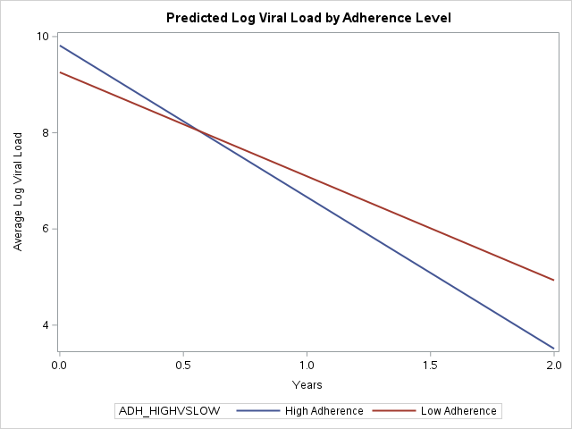

**log**

```
109                                                        The SAS System                      Friday, December 19, 2025 03:23:00 AM

1048       ods listing close;ods html5 (id=saspy_internal) file=_tomods1 options(bitmap_mode='inline') device=svg style=HTMLBlue;
1048     ! ods graphics on / outputfmt=png;
1049
1050       * Visualize the predicted values under the final model;
1051       PROC SGPLOT DATA = Proj2LMM.Data;
1052        REG X = Years Y = Predicted_VLOAD_log / GROUP = ADH_HIGHVSLOW LINEATTRS = (THICKNESS=2) NOMARKERS;
1053        XAXIS LABEL = "Years";
1054        YAXIS LABEL = "Average Log Viral Load";
1055        TITLE "Predicted Log Viral Load by Adherence Level";
1056        RUN;
1057
1058
1059       ods html5 (id=saspy_internal) close;ods listing;
1060
110                                                        The SAS System                      Friday, December 19, 2025 03:23:00 AM

1061
```

Top of Tabset